# Dimarta Clinical Trial- Case Study

The R Bootcamp @ Erfurt [www.therbootcamp.com](https://therbootcamp.github.io) [@therbootcamp](https://twitter.com/therbootcamp)

### Overview

In this case study, we will look at the results of a clinical trial exploring the effectiveness of a new medication called dimarta on reducing histamine in patients with a disease that leads to chronically high histamine levels. In the study, 300 patients were assigned to one of three different treatment arms. One arm was given a placebo. The other arm was given adiclax – the standard of care for the disease. Finally, the third arm was given dimarta. There were two main measures of interest in the trial: patient’s changes in histamine from the beginning to the end of the trial, and their change in quality of life (measured by self report).

In addition to exploring the effects of the three medications, the researchers are interested in the extent to which three different biomarkers, dw, ms, and np, are correlated with therapeutic outcomes. In other words, to patients that express one or more of these biomarkers have better, or worse, outcomes that those that do not express these biomarkers?

## Data Description

The data for this case study are in three separate files: `dimarta_biomarker.csv`, `dimarta_demographics.csv`, and `dimarta_trial.csv`. Here are descriptions of the columns in these files:

**dimarta_trial.csv**

Table1. “dimarta_trial.csv” variable description:

| Variable | Description |
| --- | --- |
| PatientID | Unique patient id |
| arm | Treatment arm, either 1 = placebo, 2 = adiclax (the standard of treatment), or 3 = dimarta (the target drug) |
| histamine_start | histamine value at the start of the trial |
| histamine_end | histamine value at the end of the trial |
| qol_start | Patient’s rated quality of life at the start of the trial |
| qol_end | Patient’s rated quality of life at the end of the trial |

**dimarta_demographics.csv**

Table2. “dimarta_demographics.csv” variable description:

| Variable | Description |
| --- | --- |
| PatientID | Unique patient id |
| age | Patient age |
| gender | Patient gender, 0 = male, 1 = female |
| site | Site where the clinical trial was conducted |
| diseasestatus | Status of the patient’s disease at start of trial |

**dimarta_biomarker.csv**

Table3. “dimarta_biomarker.csv” variable description:

| Variable | Description |
| --- | --- |
| PatientID | Unique patient id |
| Biomarker | One of three biomarkers: dw, ms, and np |
| BiomarkerStatus | Result of the test for the biomarker. |

### Data I/O

0. Create a new R project called `dimarta`. In that project, create two folders: `R` and `data`.
1. Outside of R (e.g.; on your computer) save local copies of the three data files, `dimarta_trial.csv`, `dimarta_demographics.csv`, and`dimarta_biomarker.csv` in the `data` folder of your project.
2. Open a new R script and save it as a new file in your `R` folder called `dimarta_casestudy.R`. At the top of the script, using comments, write your name and the date. Then, load the `tidyverse` package. Here’s how the top of your script should look:

```r
## My Name
## The Date
## Dimarta - Case Study

library(tidyverse)
```

3. Using `read_csv()`, load the `dimarta_trial.csv`, `dimarta_demographics.csv`, and `dimarta_biomarker.csv` datasets as *three* new objects called `trial_df`, `demographics_df`, and `biomarker_df`.

```r
trial_df <- read_csv(file = "data/dimarta_trial.csv")
demographics_df <- read_csv(file = "data/dimarta_demographics.csv")
biomarker_df <- read_csv(file = "data/dimarta_biomarker.csv")
```

4. Get a first impression of the objects you just created by exploring them with a mixture of the `View()`, `head()`, `names()`, and `str()` functions. Were they all loaded correctly?

```r
trial_df
```

```
## # A tibble: 300 x 6
##    PatientID arm   histamine_start histamine_end qol_start qol_end
##    <chr>     <chr>           <dbl>         <dbl>     <int>   <int>
##  1 txdjezeo  I                58.6          67.0         3       3
##  2 htxfjlxk  III              36.1          28.0         3       4
##  3 vkdqhyez  I                57.7          57.3         2       2
##  4 dbuvrwfq  III              56.6          57.4         2       3
##  5 ydaitaah  II               NA            67.9         5       7
##  6 omhxokdr  I                37.4          41.7         2       2
##  7 dsybafny  I                88.4          95.9         4       6
##  8 fdfmcoto  II               20.2          18.9         2       2
##  9 rwsbykxe  II               48.3          43.0         3       3
## 10 xocueqqe  III              48.6          55.2         1       1
## # ... with 290 more rows
```

```r
demographics_df
```

```
## # A tibble: 300 x 5
##    PatientID   age gender site   diseasestatus
##    <chr>     <int>  <int> <chr>  <chr>
##  1 pkyivajv     36      0 Tokyo  Mid
##  2 dbuvrwfq     39      0 Paris  Late
##  3 jhuztppp     30      0 Tokyo  Mid
##  4 qejexgza     34      1 Tokyo  Late
##  5 cszrjxju     41      1 Tokyo  Late
##  6 uhvgttqh     31      0 London Late
##  7 cflnybdw     45      1 Tokyo  Mid
##  8 igobmmvj     48      0 Tokyo  Late
##  9 lcrtmerg     35      0 London Late
## 10 fjjrnsnt     43      1 London Mid
## # ... with 290 more rows
```

```r
biomarker_df
```

```
## # A tibble: 900 x 3
##    PatientID Biomarker BiomarkerStatus
##    <chr>     <chr>     <lgl>
##  1 ygazqssv  dw        FALSE
##  2 qosueuyw  ms        FALSE
##  3 bhhykjvw  ms        FALSE
##  4 ifajorty  np        TRUE
##  5 gxnsybdt  ms        FALSE
##  6 igobmmvj  ms        FALSE
##  7 knnzlzun  ms        FALSE
##  8 glzcbmby  ms        FALSE
##  9 gxnsybdt  dw        TRUE
## 10 fzrhdpdu  np        FALSE
## # ... with 890 more rows
```

### Data Wrangling

5. Using `rename()`, change the name of the column `arm` in the `trial_df` data to `StudyArm`.

```r
trial_df <- trial_df %>%
  rename(StudyArm = arm)
```

```r
trial_df <- trial_df %>%
  mutate(StudyArm = case_when(
    StudyArm == "I" ~ "placebo",
    StudyArm == "II" ~ "adiclax",
    StudyArm == "III" ~ "dimarta"
  ))
```

7. In the `demographics_df` data, you’ll see that gender is coded as 0 and 1. Using `mutate()` create a *new* column in `demographics_df` called `gender_c` that shows gender as a string, where 0 = “male”, and 1 = “female”.

```r
demographics_df <- demographics_df %>%
  mutate(gender_c = case_when(
    gender == 0 ~ "male",
    gender == 1 ~ "female"
  ))
```

8. Now let’s create a new object called `dimarta_df` that combines data from `trial_df` and `demographics_df`. To do this, use `left_join()` to combine the `trial_df` data with the `demographics_df` data. This will merge the two datasets so you can have the study results and demographic data in the same dataframe. Make sure to assign the result to a new object called `dimarta_df`

```r
# Create a new dataframe called dimarta_df that contains both trial_df and demographics_df
dimarta_df <- trial_df %>%
  left_join(demographics_df)
```

9. You’ll notice that the `biomarker_df` dataframe is in the ‘long’ format, where each row is a patient’s biomarker result. Using the code below, making use of the `spread()` function, create a new dataframe called `biomarker_wide_df` where each row is a patient, and the results from different biomarkers are in different columns. When you finish, look at `biomarker_wide_df` to see how it looks!

```r
# Convert biomarker_df to a wide format using spread()
biomarker_wide_df <- biomarker_df %>%
  spread(Biomarker, BiomarkerStatus)

biomarker_wide_df
```

```
## # A tibble: 300 x 4
##    PatientID dw    ms    np
##    <chr>     <lgl> <lgl> <lgl>
##  1 aiadwpbo  FALSE FALSE FALSE
##  2 ajshuufj  FALSE FALSE FALSE
##  3 ammweoxu  FALSE FALSE FALSE
##  4 amzacliz  FALSE FALSE FALSE
##  5 apeddxgo  TRUE  FALSE FALSE
##  6 aqadnoup  TRUE  FALSE FALSE
##  7 arinkxww  FALSE FALSE FALSE
##  8 arpvtvxl  FALSE FALSE FALSE
##  9 asquxnty  FALSE FALSE TRUE
## 10 atzluemr  FALSE FALSE FALSE
## # ... with 290 more rows
```

10. Now, using the `left_join` function, add the `biomarker_wide_df` data to the `dimarta_df` data! Now you should hve all of the data in a single dataframe called `dimarta_df`

```r
dimarta_df <- dimarta_df %>%
  left_join(biomarker_wide_df)
```

```r
dimarta_df
```

```
## # A tibble: 300 x 14
##    PatientID StudyArm histamine_start histamine_end qol_start qol_end   age
##    <chr>     <chr>              <dbl>         <dbl>     <int>   <int> <int>
##  1 txdjezeo  placebo             58.6          67.0         3       3    39
##  2 htxfjlxk  dimarta             36.1          28.0         3       4    42
##  3 vkdqhyez  placebo             57.7          57.3         2       2    47
##  4 dbuvrwfq  dimarta             56.6          57.4         2       3    39
##  5 ydaitaah  adiclax             NA            67.9         5       7    35
##  6 omhxokdr  placebo             37.4          41.7         2       2    41
##  7 dsybafny  placebo             88.4          95.9         4       6    35
##  8 fdfmcoto  adiclax             20.2          18.9         2       2    50
##  9 rwsbykxe  adiclax             48.3          43.0         3       3    35
## 10 xocueqqe  dimarta             48.6          55.2         1       1    42
## # ... with 290 more rows, and 7 more variables: gender <int>, site <chr>,
## #   diseasestatus <chr>, gender_c <chr>, dw <lgl>, ms <lgl>, np <lgl>
```

12. Using `write_csv()`, save `dimarta_df` in a new `.csv` file in your `data` folder called `dimarta.csv`

```r
write_csv(x = dimarta_df,
          path = "data/dimarta.csv")
```

13. Using the `mean()` function, calculate the mean age of all patients.

```r
mean(dimarta_df$age)
```

```
## [1] 39.93333
```

14. Using the following template, find out how many male and female patients were in the trial.

```r
dimarta_df %>%
  group_by(XXX) %>%
  summarise(
    Counts = n()
  )
```

```r
dimarta_df %>%
  group_by(gender_c) %>%
  summarise(
    Counts = n()
  )
```

```
## # A tibble: 2 x 2
##   gender_c Counts
##   <chr>     <int>
## 1 female      140
## 2 male        160
```

15. Now, using similar code, find out how many patients were assigned to each study arm.

```r
dimarta_df %>%
  group_by(StudyArm) %>%
  summarise(
    Counts = n()
  )
```

```
## # A tibble: 3 x 2
##   StudyArm Counts
##   <chr>     <int>
## 1 adiclax     100
## 2 dimarta     100
## 3 placebo     100
```

16. Find out how many men and women were assigned to each study arm (Hint: You can use very similar code to what you used above, just add a second grouping variable!)

```r
dimarta_df %>%
  group_by(StudyArm, gender_c) %>%
  summarise(
    Counts = n()
  )
```

```
## # A tibble: 6 x 3
## # Groups:   StudyArm [?]
##   StudyArm gender_c Counts
##   <chr>    <chr>     <int>
## 1 adiclax  female       41
## 2 adiclax  male         59
## 3 dimarta  female       49
## 4 dimarta  male         51
## 5 placebo  female       50
## 6 placebo  male         50
```

17. Using `mutate()`, add a new column to the `dimarta_df` data called `histamine_change` that shows the *change* in patient’s histamine levels from the start to the end of the trial (Hint: just subtract `histamine_start` from `histamine_end`!)

```r
dimarta_df <- dimarta_df %>%
  mutate(
    histamine_change = histamine_end - histamine_start
  )

# Look at result
dimarta_df %>%
  select(histamine_change)
```

```
## # A tibble: 300 x 1
##    histamine_change
##               <dbl>
##  1            8.4
##  2           -8.12
##  3           -0.39
##  4            0.760
##  5           NA
##  6            4.34
##  7            7.47
##  8           -1.35
##  9           -5.32
## 10            6.58
## # ... with 290 more rows
```

18. Using `mutate()` again, add a new column to `dimarta_df` called `qol_change` that shows the change in patient’s quality of life.

```r
dimarta_df <- dimarta_df %>%
  mutate(
    qol_change = qol_end - qol_start
  )

# Look at result
dimarta_df %>%
  select(qol_change)
```

```
## # A tibble: 300 x 1
##    qol_change
##         <int>
##  1          0
##  2          1
##  3          0
##  4          1
##  5          2
##  6          0
##  7          2
##  8          0
##  9          0
## 10          0
## # ... with 290 more rows
```

19. Calculate the percentage of patients who tested positive for each of the three biomarkers using the following template (Hint: If you calculate the `mean()` of a logical vector, you will get the percentage of TRUE values!)

```r
# Calculate percent of patients with positive biomarkers

dimarta_df %>%
  summarise(
    dw_mean = mean(XXX),
    ms_percent = mean(XXX),
    np_percent = mean(XXX)
  )
```

```r
# Calculate percent of patients with positive biomarkers

dimarta_df %>%
  summarise(
    dw_mean = mean(dw),
    ms_percent = mean(ms),
    np_percent = mean(np)
  )
```

```
## # A tibble: 1 x 3
##   dw_mean ms_percent np_percent
##     <dbl>      <dbl>      <dbl>
## 1   0.257       0.19      0.233
```

20. Were there different distributions of age in the different trial sites? To answer this, separately calculate the mean and standard deviations of patient ages in each site. (Hint: group the data by `site`, then calculate two separate summary statistics: `age_mean = mean(age)`, and `age_sd = sd(age)`.

```r
# Calculate the mean change in histamine for each study site
dimarta_df %>%
  group_by(site) %>%
  summarise(
    age_mean = mean(age),
    age_sd = sd(age)
  )
```

```
## # A tibble: 3 x 3
##   site   age_mean age_sd
##   <chr>     <dbl>  <dbl>
## 1 London     39.9   5.86
## 2 Paris      39.8   4.84
## 3 Tokyo      40.1   4.50
```

21. Calculate the mean change in histamine results separately for each study site

```r
# Calculate the mean change in histamine for each study site
dimarta_df %>%
  group_by(site) %>%
  summarise(
    histamine_change_mean = mean(histamine_change, na.rm = TRUE)
  )
```

```
## # A tibble: 3 x 2
##   site   histamine_change_mean
##   <chr>                  <dbl>
## 1 London                 -6.32
## 2 Paris                  -4.93
## 3 Tokyo                   1.19
```

22. Calculate the mean change in histamine results (`histamine_change`) for each study arm. Which study arm had a largest decrease in histamine?

```r
# Calculate the mean change in histamine for each study site
dimarta_df %>%
  group_by(StudyArm) %>%
  summarise(
    histamine_change_mean = mean(histamine_change, na.rm = TRUE)
  )
```

```
## # A tibble: 3 x 2
##   StudyArm histamine_change_mean
##   <chr>                    <dbl>
## 1 adiclax                 -18.1
## 2 dimarta                   5.00
## 3 placebo                   2.74
```

23. Calculate the mean change in quality of life (`qol_change`) for each study arm. Do the results match what you found with the histamine results?

```r
# Calculate the mean change in histamine for each study site
dimarta_df %>%
  group_by(StudyArm) %>%
  summarise(
    qol_change_mean = mean(qol_change, na.rm = TRUE)
  )
```

```
## # A tibble: 3 x 2
##   StudyArm qol_change_mean
##   <chr>              <dbl>
## 1 adiclax             0.06
## 2 dimarta             0.01
## 3 placebo            -0.15
```

### Plotting

24. Run the following code block to visualise the relationship between study arm and histamine change. What do you find?

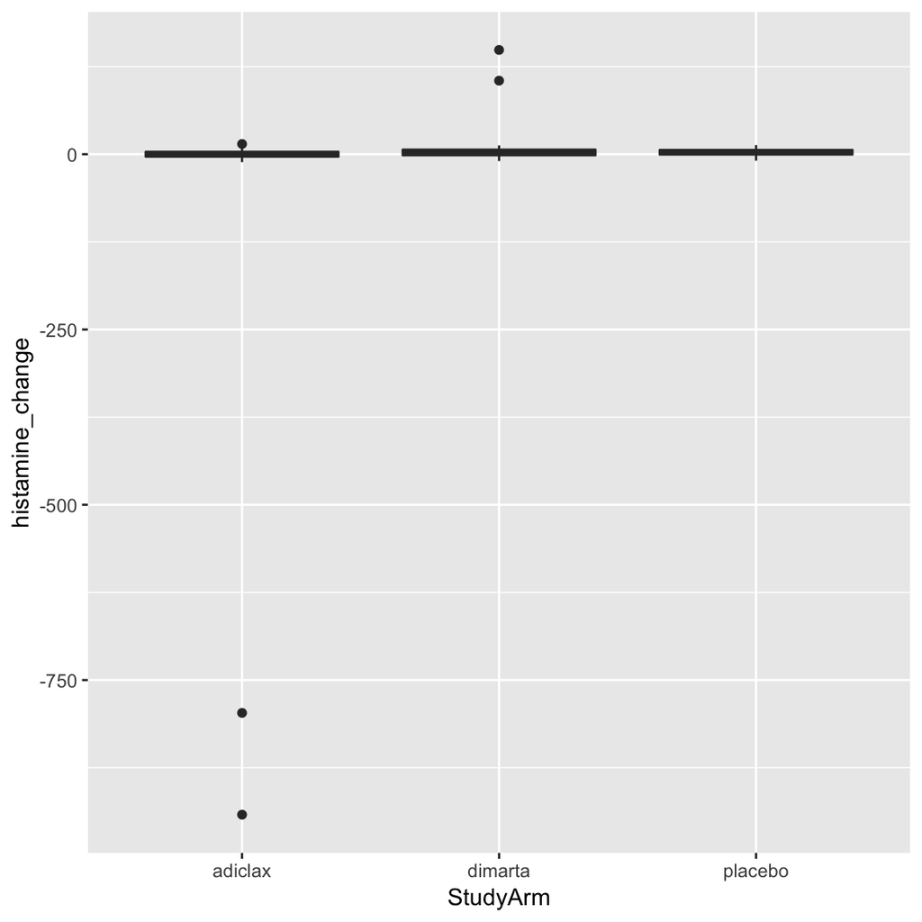

```r
ggplot(data = dimarta_df,
       mapping = aes(x = StudyArm, y = histamine_change)) +
  geom_boxplot()
```

### Statistics

24. Using `t.test()` conduct a t-test comparing the change in histamine results between the placebo and dimarta. Did dimarta differ from the placebo?

```r
# T.test comparing change in histamine between placebo and dimarta

t.test(formula = XX ~ XX,
       data = XXX %>%
              filter(XXX %in% c(XXX, XXX)))  # Only include placebo and dimarta
```

```r
# T.test comparing change in histamine between placebo and dimarta

t.test(formula = histamine_change ~ StudyArm,
       data = dimarta_df %>%
              filter(StudyArm %in% c("placebo", "dimarta")))  # Only include placebo and dimarta
```

```
##
##  Welch Two Sample t-test
##
## data:  histamine_change by StudyArm
## t = 1.1067, df = 103.48, p-value = 0.271
## alternative hypothesis: true difference in means is not equal to 0
## 95 percent confidence interval:
##  -1.796015  6.331505
## sample estimates:
## mean in group dimarta mean in group placebo
##              5.002903              2.735158
```

25. Using `t.test()` conduct a t-test comparing the change in histamine results between the adiclax (the standard of care) and dimarta. Did dimarta improve over the standard of care?

```r
# T.test comparing change in histamine between placebo and dimarta

t.test(formula = histamine_change ~ StudyArm,
       data = dimarta_df %>%
              filter(StudyArm %in% c("adiclax", "dimarta")))  # Only include placebo and dimarta
```

```
##
##  Welch Two Sample t-test
##
## data:  histamine_change by StudyArm
## t = -1.7672, df = 98.439, p-value = 0.0803
## alternative hypothesis: true difference in means is not equal to 0
## 95 percent confidence interval:
##  -49.080454   2.841595
## sample estimates:
## mean in group adiclax mean in group dimarta
##            -18.116526              5.002903
```

26. Using `glm()` conduct a regression analysis predicting `histamine_change` as a function of 4 variables: treatment arm, histamine test results at the start of the trial, age, and quality of life at the start of the trial. Save the result as an object called `histamine_change_glm`. Once you do, apply the `summary()` function to the `histamine_change_glm` object to explore the results. Which variables reliably predict changes in test results?

```r
histamine_change_glm <- glm(histamine_change ~ StudyArm + histamine_start + qol_start + age,
                            data = dimarta_df)

summary(histamine_change_glm)
```

```
##
## Call:
## glm(formula = histamine_change ~ StudyArm + histamine_start +
##     qol_start + age, data = dimarta_df)
##
## Deviance Residuals:
##     Min       1Q   Median       3Q      Max
## -59.075  -10.134   -0.009   10.828   46.744
##
## Coefficients:
##                 Estimate Std. Error t value Pr(>|t|)
## (Intercept)     45.03000    8.99445   5.006 9.88e-07 ***
## StudyArmdimarta  5.40640    2.48974   2.171   0.0307 *
## StudyArmplacebo  3.27689    2.48251   1.320   0.1879
## histamine_start -0.92895    0.01331 -69.774  < 2e-16 ***
## qol_start       -0.53305    1.01285  -0.526   0.5991
## age              0.03947    0.20372   0.194   0.8465
## ---
## Signif. codes:  0 '***' 0.001 '**' 0.01 '*' 0.05 '.' 0.1 ' ' 1
##
## (Dispersion parameter for gaussian family taken to be 288.1988)
##
##     Null deviance: 1559910  on 282  degrees of freedom
## Residual deviance:   79831  on 277  degrees of freedom
##   (17 observations deleted due to missingness)
## AIC: 2413.9
##
## Number of Fisher Scoring iterations: 2
```

27. Repeat your previous regression analysis, but now predict change in quality of life. Do you get different results compared to your previous analysis?

```r
qol_change_glm <- glm(qol_change ~ StudyArm + histamine_start + qol_start + age,
                            data = dimarta_df)

summary(qol_change_glm)
```

```
##
## Call:
## glm(formula = qol_change ~ StudyArm + histamine_start + qol_start +
##     age, data = dimarta_df)
##
## Deviance Residuals:
##     Min       1Q   Median       3Q      Max
## -3.0719  -0.7913   0.0154   0.2833   2.9612
##
## Coefficients:
##                   Estimate Std. Error t value Pr(>|t|)
## (Intercept)      3.390e-01  4.811e-01   0.705    0.482
## StudyArmdimarta -2.372e-02  1.356e-01  -0.175    0.861
## StudyArmplacebo -1.805e-01  1.345e-01  -1.342    0.181
## histamine_start -5.547e-05  5.933e-04  -0.094    0.926
## qol_start        3.769e-02  5.561e-02   0.678    0.498
## age             -1.074e-02  1.093e-02  -0.983    0.327
##
## (Dispersion parameter for gaussian family taken to be 0.8854165)
##
##     Null deviance: 257.33  on 292  degrees of freedom
## Residual deviance: 254.11  on 287  degrees of freedom
##   (7 observations deleted due to missingness)
## AIC: 803.78
##
## Number of Fisher Scoring iterations: 2
```

28. Now it’s time to see if the patient’s biomarkers were related to treatment success. For the `dw` biomarker, calculate the mean change in test results (`histamine_change`) separately for patients with different outcomes on the `dw` biomarker (hint: just group the data by `dw` and use `summarise()` to calculate the mean `histamine_change`).

```r
dimarta_df %>%
  group_by(dw) %>%
  summarise(
    histamine_change_mean = mean(histamine_change, na.rm = TRUE)
  )
```

```
## # A tibble: 2 x 2
##   dw    histamine_change_mean
##   <lgl>                 <dbl>
## 1 FALSE                 -5.40
## 2 TRUE                   1.98
```

29. Do the same analysis for the other two biomarkers `ms` and `np`. Do either of these biomarkers seem to predict changes in test results?

```r
dimarta_df %>%
  group_by(ms) %>%
  summarise(
    histamine_change_mean = mean(histamine_change, na.rm = TRUE)
  )
```

```
## # A tibble: 2 x 2
##   ms    histamine_change_mean
##   <lgl>                 <dbl>
## 1 FALSE                -0.725
## 2 TRUE                -14.8
```

```r
dimarta_df %>%
  group_by(np) %>%
  summarise(
    histamine_change_mean = mean(histamine_change, na.rm = TRUE)
  )
```

```
## # A tibble: 2 x 2
##   np    histamine_change_mean
##   <lgl>                 <dbl>
## 1 FALSE                 -5.21
## 2 TRUE                   2.37
```

30. Using `glm()`, create a new regression object called `histamine_change_bio_glm` predicting `histamine_change` as a function of the 3 biomarkers. Explore the results with `summary()`. Do you find that any of these biomarkers predict changes in histamine?

```r
histamine_change_bio_glm <- glm(histamine_change ~ dw + np + ms,
                                data = dimarta_df)

summary(histamine_change_bio_glm)
```

```
##
## Call:
## glm(formula = histamine_change ~ dw + np + ms, data = dimarta_df)
##
## Deviance Residuals:
##     Min       1Q   Median       3Q      Max
## -923.20    -0.86     4.35    10.31   153.16
##
## Coefficients:
##             Estimate Std. Error t value Pr(>|t|)
## (Intercept)   -4.390      6.055  -0.725    0.469
## dwTRUE         7.209     10.161   0.709    0.479
## npTRUE         8.470     10.650   0.795    0.427
## msTRUE       -14.399     11.122  -1.295    0.197
##
## (Dispersion parameter for gaussian family taken to be 5536.842)
##
##     Null deviance: 1559910  on 282  degrees of freedom
## Residual deviance: 1544779  on 279  degrees of freedom
##   (17 observations deleted due to missingness)
## AIC: 3248.3
##
## Number of Fisher Scoring iterations: 2
```

31. Did some drugs work better for patients with some biomarkers than others? For example, did patients who expressed the `dw` biomarker have better results when given dimarta compared to patients who do not express the `dw` biomarker? To answer this, start by calculating the descriptive statistics by calculating mean change in histamine `histamine_change` for all groups of `dw` and `StudyArm` (Hint: Just use `group_by(dw, StudyArm)` and `summarise(histamine_change_mean = mean(histamine_change))`).

```r
dimarta_df %>%
  group_by(dw, StudyArm) %>%
  summarise(
    histamine_change_mean = mean(histamine_change, na.rm = TRUE)
  )
```

```
## # A tibble: 6 x 3
## # Groups:   dw [?]
##   dw    StudyArm histamine_change_mean
##   <lgl> <chr>                    <dbl>
## 1 FALSE adiclax                -25.5
## 2 FALSE dimarta                  5.67
## 3 FALSE placebo                  2.61
## 4 TRUE  adiclax                  0.530
## 5 TRUE  dimarta                  2.57
## 6 TRUE  placebo                  3.08
```

32. Once you’ve looked at the descriptive statistics, conduct a regression analysis predicting `histamine_change` based on the *interaction* between `dw` and `StudyArm`. Remember to calculate an interaction term in regression, use the `*` symbol in the formula. What do the results show?

```r
dw_arm_glm <- glm(histamine_change ~ dw * StudyArm,
                  data = dimarta_df)

summary(dw_arm_glm)
```

```
##
## Call:
## glm(formula = histamine_change ~ dw * StudyArm, data = dimarta_df)
##
## Deviance Residuals:
##     Min       1Q   Median       3Q      Max
## -916.47    -3.30     1.02     9.98   143.10
##
## Coefficients:
##                        Estimate Std. Error t value Pr(>|t|)
## (Intercept)             -25.520      8.971  -2.845  0.00478 **
## dwTRUE                   26.050     16.828   1.548  0.12275
## StudyArmdimarta          31.189     12.468   2.502  0.01294 *
## StudyArmplacebo          28.131     12.596   2.233  0.02632 *
## dwTRUE:StudyArmdimarta  -29.144     25.135  -1.159  0.24725
## dwTRUE:StudyArmplacebo  -25.579     24.089  -1.062  0.28922
## ---
## Signif. codes:  0 '***' 0.001 '**' 0.01 '*' 0.05 '.' 0.1 ' ' 1
##
## (Dispersion parameter for gaussian family taken to be 5472.662)
##
##     Null deviance: 1559910  on 282  degrees of freedom
## Residual deviance: 1515927  on 277  degrees of freedom
##   (17 observations deleted due to missingness)
## AIC: 3247
##
## Number of Fisher Scoring iterations: 2
```